# Aviation Accidents

Radvilas Mikonis 5/18/2020

[figure not shown]

ISTOCK

Aviation is a relatively recent advancement in human history, however, it has become one of the most important ways people travel and connect across the world. This reliance on aviation has brought with it the requirement for high reliability and safety. However, accidents still occur and are carefully documented in order to explore the factors that contributed to these events. As time has went on, new regulations and improvements in technology should have made air travel safer for all. But is this a case? We can use the NTSB aviation accident information to see the locations, accidents, and the extent of injuries and casualties from these events. We should make the distinction that since we are not monitoring flying as whole, we cannot make meaningful inferences into the reliability of individual aircraft, so we will look at the extent of injuries and fatalities over time to see if the chances of surviving an aviation accident have increased, and if so, to what extent the make of the aircraft influences this.

# Data

First we will want to gather our data that we will be able to analyze and hopefully answer our questions. There are two methods to obtain data, one way is to scrape data directly from websites and then organize it into a database by yourself. The other option is to find a file that contains the information for us.

We will opt for the second option as the data is already available so it would be easier to make use of existing data rather than try to create our own database.

So, since aviation data is something that is fairly important to aviation regulatory and safety bodies, we can find a dataset at the [NTSB](https://www.ntsb.gov/_layouts/ntsb.aviation/index.aspx) site.

They provide the dataset in a file called "AviationData.txt". We can download the file and open it up locally, noting that the delimiter being used is the "|" character. Knowing this we provide the path to the text file and the delimeter, we can now open the data set in python:

More info on pandas dataframes can be found [here](https://www.tutorialspoint.com/python_pandas/python_pandas_dataframe.htm).

```python
import pandas as pd
import sqlite3
from plotnine import *
from mizani.palettes import *
from palettable import *
import matplotlib.pyplot as plt
import warnings
import numpy as np
import statsmodels.api as sm
from statsmodels.formula.api import ols
from statsmodels.sandbox.regression.predstd import wls_prediction_std

warnings.filterwarnings('ignore')
df = pd.read_csv("C:/tmp/AviationData.txt",delimiter='|')
# We set the option to display all the columns, so we could fully inspect it.
pd.set_option('display.max_columns', None)
```

```python
df.head(25)
```

|  | Event Id | Investigation Type | Accident Number | Event Date | Location | Country | Latitude | Longitude | Airport Code | Airport Name | Injury Severity | Aircraft Damage | Aircraft Category | Registration Number | Make | Model | Amateur Built | Number of Engines | Engine Type | FAR Description | Schedule | Purpose of Flight | Air Carrier | Total Fatal Injuries | Total Serious Injuries | Total Minor Injuries | Total Uninjured | Weather Condition | Broad Phase of Flight | … |
| --- | --- | --- | --- | --- | --- | --- | --- | --- | --- | --- | --- | --- | --- | --- | --- | --- | --- | --- | --- | --- | --- | --- | --- | --- | --- | --- | --- | --- | --- | --- |
| 0 | 20200509X11853 | Accident | CEN20LA173 | 05/09/2020 | Haskell, OK | United States | 35.864167 | -95.655556 | 2K9 | HASKELL | Non-Fatal | Substantial | Airplane | N318WH | Titan | TITAN TORNADO S | Yes |  |  | Part 91: General Aviation |  | Personal |  |  | 1 |  |  | VMC | DESCENT | … |
| 1 | 20200508X55730 | Accident | CEN20CA176 | 05/08/2020 | San Antonio, TX | United States | 29.723334 | -98.694444 | 5C1 |  | Unavailable | Substantial | Airplane | N3238G | North American | SNJ | No |  |  | Part 91: General Aviation |  | Personal |  |  |  |  |  |  |  | … |
| 2 | 20200507X60215 | Accident | CEN20CA174 | 05/06/2020 | Gonazales, TX | United States | 29.529167 | -97.464167 | T20 | Roger M Dreyer Memorial | Non-Fatal | Substantial | Airplane | N25HE | CESSNA | T240 | No | 1 |  | Part 91: General Aviation |  | Personal |  |  |  |  | 2 | VMC |  | … |
| 3 | 20200509X85739 | Accident | ERA20CA175 | 05/03/2020 | Shirley, NY | United States | 40.828056 | -72.865556 | HWV | BROOKHAVEN | Non-Fatal | Substantial | Airplane | N11457 | Waco | QCF | No | 1 |  | Part 91: General Aviation |  | Personal |  |  |  |  | 1 | VMC |  | … |
| 4 | 20200504X54503 | Incident | ENG20IA031 | 05/03/2020 | Clewiston, FL | United States | 26.735000 | -81.051111 |  |  | Incident |  | Helicopter | N1WT | AIRBUS HELICOPTERS | AS350 | No | 1 | Turbo Shaft | Part 91: General Aviation |  | Personal |  |  |  |  | 1 |  |  | … |
| 5 | 20200504X13237 | Accident | ERA20CA168 | 05/02/2020 | Bowling Green, KY | United States |  |  | BWG |  | Unavailable | Substantial | Airplane | N32517 | DAYTON-WRIGHT | DH-4 | No |  |  | Part 91: General Aviation |  |  |  |  |  |  |  |  |  | … |
| 6 | 20200502X81549 | Accident | CEN20LA168 | 05/02/2020 | PALMYRA, IL | United States | 39.408889 | -89.990277 | 5K1 | Zelmer Memorial Airpark Inc | Fatal(1) | Destroyed | Airplane | N27YK | Yakovlev | YAK 52 | No | 1 | Reciprocating | Part 91: General Aviation |  | Personal |  | 1 |  |  |  | VMC | MANEUVERING | … |
| 7 | 20200502X73540 | Accident | CEN20LA167 | 05/02/2020 | HOUSTON, TX | United States | 29.947222 | -95.395833 |  | N/A | Fatal(1) | Substantial | Helicopter | N8375F | MD HELICOPTER | 369 | No | 1 | Turbo Shaft | Public Aircraft |  | Public Aircraft - Local |  | 1 | 1 |  |  | VMC | UNKNOWN | … |
| 8 | 20200504X03044 | Accident | ERA20WA167 | 05/01/2020 | Dnipropetrovsk, Ukraine | Ukraine | 48.552500 | 35.017223 |  | Kamyanka Airfield | Fatal(2) | Substantial | Airplane |  | GRUMMAN | AA5 | No |  |  | Non-U.S., Non-Commercial |  |  |  | 2 |  |  |  |  | LANDING | … |
| 9 | 20200430X12813 | Accident | CEN20CA164 | 04/30/2020 | ANOKA, MN | United States | 45.295555 | -93.173611 |  | N/A | Non-Fatal | Substantial | Airplane | N1669M | Cessna | A185 | No | 1 | Reciprocating | Part 91: General Aviation |  | Personal |  |  |  | 1 |  | VMC | LANDING | … |
| 10 | 20200507X54716 | Accident | ANC20CA045 | 04/30/2020 | Anchorage, AK | United States | 61.215833 | -149.841944 | MRI | MERRILL FIELD | Non-Fatal | Substantial | Airplane | N91040 | GRUMMAN | G44 | No | 2 |  | Part 91: General Aviation |  | Personal |  |  |  |  | 3 | VMC |  | … |
| 11 | 20200429X05114 | Accident | WPR20LA133 | 04/28/2020 | Lodi, CA | United States | 38.196111 | -121.248889 |  | N/A | Non-Fatal | Substantial | Airplane | N3386T | Cessna | 177 | No | 1 | Reciprocating | Part 91: General Aviation |  | Personal |  |  |  | 1 |  | VMC | CRUISE | … |
| 12 | 20200428X34430 | Accident | CEN20LA162 | 04/28/2020 | New Braunfels, TX | United States | 29.867778 | -98.275834 |  | N/A | Non-Fatal | Substantial | Airplane | N210HH | Cessna | 210 | No | 1 | Reciprocating | Part 91: General Aviation |  | Personal |  |  |  | 1 | 1 | IMC | CRUISE | … |
| 13 | 20200427X25753 | Accident | WPR20LA132 | 04/27/2020 | Upland, CA | United States | 34.111667 | -117.687500 | CCB | Cable | Non-Fatal | Substantial | Airplane | N1222C | COOK | SONEX | Yes |  | Reciprocating | Part 91: General Aviation |  | Personal |  |  |  |  | 1 | VMC | TAKEOFF | … |
| 14 | 20200428X65122 | Accident | ERA20LA164 | 04/27/2020 | Meridianville, AL | United States | 34.845833 | -86.557778 | MDQ | Huntsville Executive Tom Sharp | Non-Fatal | Substantial | Airplane | N772SG | Piper | PA32RT | No | 1 | Reciprocating | Part 91: General Aviation |  | Personal |  |  |  |  | 1 | VMC | APPROACH | … |
| 15 | 20200430X54513 | Accident | CEN20CA163 | 04/27/2020 | Longmont, CO | United States | 40.163611 | -105.162222 | LMO | VANCE BRAND | Non-Fatal | Substantial | Airplane | N41498 | Piper | PA28 | No | 1 | Reciprocating | Part 91: General Aviation |  | Personal |  |  |  |  | 1 | VMC | LANDING | … |
| 16 | 20200426X32853 | Accident | CEN20CA161 | 04/26/2020 | Colorado Springs, CO | United States | 38.864444 | -104.768611 | FLY | Meadow Lake | Non-Fatal | Substantial | Airplane | N1598A | Piper | PA 20 | No | 1 | Reciprocating | Part 91: General Aviation |  | Instructional |  |  |  |  | 2 | VMC | LANDING | … |
| 17 | 20200425X65834 | Accident | WPR20CA134 | 04/25/2020 | Bountiful, UT | United States | 40.863889 | -111.927500 | BTF | SKYPARK | Non-Fatal | Substantial | Airplane | N707VB | Piper | PA18 | No | 1 | Reciprocating | Part 91: General Aviation |  | Personal |  |  |  | 1 |  | VMC | LANDING | … |
| 18 | 20200427X62554 | Accident | ERA20LA163 | 04/25/2020 | East Hampton, NY | United States | 40.959444 | -72.251667 | HTO | EAST HAMPTON | Non-Fatal | Substantial | Airplane | N33005 | Piper | PA28 | No | 1 | Reciprocating | Part 91: General Aviation |  | Personal |  |  |  |  | 3 | VMC | APPROACH | … |
| 19 | 20200427X63502 | Accident | ERA20LA160 | 04/25/2020 | Pylesville, MD | United States | 39.697222 | -76.392777 |  | N/A | Non-Fatal | Substantial | Helicopter | N9159F | Hughes | 369 | No | 1 | Turbo Shaft | Part 133: Rotorcraft Ext. Load |  | External Load |  |  |  |  | 1 | VMC | MANEUVERING | … |
| 20 | 20200427X62351 | Accident | ERA20CA159 | 04/25/2020 | Enosburg, VT | United States | 44.923056 | -72.753889 | PVT | Enosburg Air Field | Non-Fatal | Substantial | Airplane | N83216 | Aeronca | 7AC | No | 1 | Reciprocating | Part 91: General Aviation |  | Personal |  |  |  |  | 1 | VMC | LANDING | … |
| 21 | 20200427X70009 | Accident | ERA20LA162 | 04/24/2020 | Fort Lauderdale, FL | United States | 26.197222 | -80.170834 | FXE | Fort Lauderdale Executive | Non-Fatal | Substantial | Airplane | YV3427 | IAI | 1125 | No | 2 | Turbo Fan | Part 91: General Aviation |  | Personal |  |  |  |  | 3 | VMC | TAKEOFF | … |
| 22 | 20200427X65715 | Accident | ERA20LA161 | 04/24/2020 | Coden, AL | United States | 30.376945 | -88.157500 |  | N/A | Non-Fatal | Substantial | Airplane | N43310 | Keuthan Aircraft Corp | Buccaneer II | No | 1 | Reciprocating | Part 91: General Aviation |  | Personal |  |  |  |  | 1 | VMC |  | … |
| 23 | 20200424X73852 | Accident | CEN20LA160 | 04/23/2020 | Craig, CO | United States | 40.951944 | -108.340277 |  | N/A | Fatal(1) | Destroyed | Airplane | N601X | Piper | PA60 | No | 2 |  | Part 91: General Aviation |  | Personal |  | 1 |  |  |  |  | UNKNOWN | … |
| 24 | 20200423X81031 | Accident | CEN20LA159 | 04/23/2020 | Mesquite, TX | United States |  |  | HQZ | Mesquite Metro | Non-Fatal | Substantial | Airplane | N477SS | Pilatus | PC12 | No | 1 | Turbo Prop | Part 91: General Aviation |  | Business |  |  | 1 |  |  | VMC | CLIMB | … |

It is important to look over the dataset and make a note of how complete it is, and the significance of the values provided.

Right away we notice a problem. It appears that our dataset is missing values in some areas, and that some of the data is not properly formatted, which will make analysis more difficult going forward if we don't correct these issues.

For example, we have some columns that provide the numbers for the amount of people that were injured or fatally wounded. In some cases, we see 0's in some columns, while in other cases we see absent values. Does this mean there were also 0 people injured or do we just not know?

Before we can proceed we will have to make some decisions as to how we want to tidy the data including:

- Which columns do we want to remove?
- What columns do we want to add?
- What columns do we want to consolidate?
- How will we treat null values?
- Is there a way to gracefully resolve the null values for some of these columns?

# Data Tidying

Some columns offer little in the way of analysis or offer unneccessary information, so we can trim them. This allows us to focus on the remaining columns without having to worry about any extra information. These columns include:

- Event Id
- Accident Number
- Airport Code
- Airport Name
- Registration Number
- Number of Engines
- Engine Type
- FAR Description
- Schedule
- Air Carrier
- Report Status
- Publication Date
- A hidden column with no title

Right away we can trim 13 columns!

Further info on data tidying in python can be found [here](https://medium.com/@aaronmak/tidying-datasets-in-python-8634f39159bc)

```python
#We refer to the columns by their index, 0 being the first column and 31 being the last column.
cols = [0,2,8,9,13,17,18,19,20,22,29,30,31]
df.drop(df.columns[cols],axis=1,inplace=True)
df.head(5)
```

|  | Investigation Type | Event Date | Location | Country | Latitude | Longitude | Injury Severity | Aircraft Damage | Aircraft Category | Make | Model | Amateur Built | Purpose of Flight | Total Fatal Injuries | Total Serious Injuries | Total Minor Injuries | Total Uninjured | Weather Condition | Broad Phase of Flight |
| --- | --- | --- | --- | --- | --- | --- | --- | --- | --- | --- | --- | --- | --- | --- | --- | --- | --- | --- | --- |
| 0 | Accident | 05/09/2020 | Haskell, OK | United States | 35.864167 | -95.655556 | Non-Fatal | Substantial | Airplane | Titan | TITAN TORNADO S | Yes | Personal |  | 1 |  |  | VMC | DESCENT |
| 1 | Accident | 05/08/2020 | San Antonio, TX | United States | 29.723334 | -98.694444 | Unavailable | Substantial | Airplane | North American | SNJ | No | Personal |  |  |  |  |  |  |
| 2 | Accident | 05/06/2020 | Gonazales, TX | United States | 29.529167 | -97.464167 | Non-Fatal | Substantial | Airplane | CESSNA | T240 | No | Personal |  |  |  | 2 | VMC |  |
| 3 | Accident | 05/03/2020 | Shirley, NY | United States | 40.828056 | -72.865556 | Non-Fatal | Substantial | Airplane | Waco | QCF | No | Personal |  |  |  | 1 | VMC |  |
| 4 | Incident | 05/03/2020 | Clewiston, FL | United States | 26.735000 | -81.051111 | Incident |  | Helicopter | AIRBUS HELICOPTERS | AS350 | No | Personal |  |  |  | 1 |  |  |

Already the dataframe is looking more manageable than before.

Next, we will want to work with the columns to begin changing the values. However, the names aren't a single string, which will give us problems. So, we rename our columns for convenience.

```python
df.columns = ['investigation_type', 'event_date', 'location', 'country', 'latitude', 'longitude', 'injury_severity', 'aircraft_damage', 'aircraft_category', 'make', 'model', 'amateur_built', 'purpose_of_flight', 'fatal_injuries', 'serious_injuries', 'minor_injuries', 'uninjured', 'weather_condition', 'phase_of_flight']
df.head(1)
```

|  | investigation_type | event_date | location | country | latitude | longitude | injury_severity | aircraft_damage | aircraft_category | make | model | amateur_built | purpose_of_flight | fatal_injuries | serious_injuries | minor_injuries | uninjured | weather_condition | phase_of_flight |
| --- | --- | --- | --- | --- | --- | --- | --- | --- | --- | --- | --- | --- | --- | --- | --- | --- | --- | --- | --- |
| 0 | Accident | 05/09/2020 | Haskell, OK | United States | 35.864167 | -95.655556 | Non-Fatal | Substantial | Airplane | Titan | TITAN TORNADO S | Yes | Personal |  | 1 |  |  | VMC | DESCENT |

Next, we want to figure out how we want to treat the null values of the injury columns. We can look at the [NTSB website](https://www.ntsb.gov/_layouts/ntsb.aviation/AviationQueryHelp.aspx) and see the description for all fields. However, it seems they give no direct information that could help us.

Instead, we can look up the most recent event, the 05/09/2020 accident at Haskell, OK and see that the [news reported](https://www.newson6.com/story/5eb6db28af61940bec0de957/ohp-troopers-respond-to-ultralight-aircraft-crash-near-haskell) only one person who was flying, the pilot, and that they suffered injuries. So we can surmise that the one person listed is the pilot and all the null values should be 0's as a result. This doesn't apply to any columns where the injury severity is unavailable. So, we will remove the columns that are list injury severity as unavailable before proceeding and then convert them to integers.

```python
df = df[~df.injury_severity.str.contains("Unavailable")]

df["fatal_injuries"] = pd.to_numeric(df["fatal_injuries"], errors='coerce')
#df["fatal_injuries"] = pd.array(df["fatal_injuries"], dtype="Int64")

df["serious_injuries"] = pd.to_numeric(df["serious_injuries"], errors='coerce')
#df["serious_injuries"] = pd.array(df["serious_injuries"], dtype="Int64")

df["minor_injuries"] = pd.to_numeric(df["minor_injuries"], errors='coerce')
#df["minor_injuries"] = pd.array(df["minor_injuries"], dtype="Int64")

df["uninjured"] = pd.to_numeric(df["uninjured"], errors='coerce')
#df["uninjured"] = pd.array(df["uninjured"], dtype="Int64")
```

Next, we can fill the injury columns with 0's in place of the NaN values.

```python
df['fatal_injuries'] = df['fatal_injuries'].fillna(0)
df['serious_injuries'] = df['serious_injuries'].fillna(0)
df['minor_injuries'] = df['minor_injuries'].fillna(0)
df['uninjured'] = df['uninjured'].fillna(0)
```

Finally, we can sum up the column values to get a total of the passengers as a new column, for use later in analysis when we want to know the ratios of injuries in the event.

```python
df.insert(17, 'total_passengers', df.apply(lambda row: row.fatal_injuries + row.serious_injuries + row.minor_injuries + row.uninjured, axis = 1))

df.head(5)
```

|  | investigation_type | event_date | location | country | latitude | longitude | injury_severity | aircraft_damage | aircraft_category | make | model | amateur_built | purpose_of_flight | fatal_injuries | serious_injuries | minor_injuries | uninjured | total_passengers | weather_condition | phase_of_flight |
| --- | --- | --- | --- | --- | --- | --- | --- | --- | --- | --- | --- | --- | --- | --- | --- | --- | --- | --- | --- | --- |
| 0 | Accident | 05/09/2020 | Haskell, OK | United States | 35.864167 | -95.655556 | Non-Fatal | Substantial | Airplane | Titan | TITAN TORNADO S | Yes | Personal | 0.0 | 1.0 | 0.0 | 0.0 | 1.0 | VMC | DESCENT |
| 2 | Accident | 05/06/2020 | Gonazales, TX | United States | 29.529167 | -97.464167 | Non-Fatal | Substantial | Airplane | CESSNA | T240 | No | Personal | 0.0 | 0.0 | 0.0 | 2.0 | 2.0 | VMC |  |
| 3 | Accident | 05/03/2020 | Shirley, NY | United States | 40.828056 | -72.865556 | Non-Fatal | Substantial | Airplane | Waco | QCF | No | Personal | 0.0 | 0.0 | 0.0 | 1.0 | 1.0 | VMC |  |
| 4 | Incident | 05/03/2020 | Clewiston, FL | United States | 26.735000 | -81.051111 | Incident |  | Helicopter | AIRBUS HELICOPTERS | AS350 | No | Personal | 0.0 | 0.0 | 0.0 | 1.0 | 1.0 |  |  |
| 6 | Accident | 05/02/2020 | PALMYRA, IL | United States | 39.408889 | -89.990277 | Fatal(1) | Destroyed | Airplane | Yakovlev | YAK 52 | No | Personal | 1.0 | 0.0 | 0.0 | 0.0 | 1.0 | VMC | MANEUVERING |

Our data set is getting better but there is still work to do. We could consider merging the make and model categories, but then we would have a hard time doing analysis on the performance of individual models, or grouping by the make. So instead, lets standardize it by setting all the values to lowercase, in case there are discrepencies in the way the these names were added to the list. We can do this for other string values in our dataset.

```python
df['make'] = df['make'].str.lower()
df['model'] = df['model'].str.lower()
df['investigation_type'] = df['investigation_type'].str.lower()
df['injury_severity'] = df['injury_severity'].str.lower()
df['aircraft_damage'] = df['aircraft_damage'].str.lower()
df['aircraft_category'] = df['aircraft_category'].str.lower()
df['amateur_built'] = df['amateur_built'].str.lower()
df['purpose_of_flight'] = df['purpose_of_flight'].str.lower()
df['weather_condition'] = df['weather_condition'].str.lower()
df['phase_of_flight'] = df['phase_of_flight'].str.lower()
```

Two columns we could merge are location and country. After we do so we could then use the resulting value in generating latitude and longitude data. We would have to disambiguate this date from the existing location datas as an approximation of where the accident occurred, rather than the exact area. To do this we would first identify the currently null latitude and longitude, create an exact coordinates column, and then use [geopy](https://geopy.readthedocs.io/en/stable/) to get an approximation of latitude and longitude from the given location by name. However, since our dataset is large, we will instead opt to just mark them as invalid with NaN, this will happen during conversion of our datatypes.

```python
df['location'] = df.apply(lambda row: row['location'] if row['country'] in row['location'] else row['location'] + ", " + row['country'], axis = 1)
df['location'] = df['location'].str.lower()
df.drop(df.columns[[3]],axis=1,inplace=True)
```

Here we will change the types of our data to match their values.

```python
df.reset_index(drop=True)
df['event_date'] = pd.to_datetime(df['event_date'], errors='coerce')
df['latitude'] = pd.to_numeric(df['latitude'], errors='coerce')
df['longitude'] = pd.to_numeric(df['longitude'], errors='coerce')
```

One thing left to do is normalize the injury_severity and purpose_of_flight as we still have mismatched categories there and then fill in NA for any other missing values in other columns. We can also add a year column to make it easier if we want to do any analysis over specific years.

```python
df['injury_severity'] = df.apply(lambda row: "non-fatal" if "non" in row['injury_severity'] else ("fatal" if "fatal" in row['injury_severity'] else ("incident" if "incident" in row['injury_severity'] else "NA")), axis = 1)
df['aircraft_damage'] = df.apply(lambda row: "NA" if row['aircraft_damage'] == '  ' else row['aircraft_damage'], axis = 1)
df['aircraft_category'] = df.apply(lambda row: "NA" if row['aircraft_category'] == '  ' else row['aircraft_category'], axis = 1)
df['make'] = df.apply(lambda row: "NA" if row['make'] == '  ' else row['make'], axis = 1)
df['model'] = df.apply(lambda row: "NA" if row['model'] == '  ' else row['model'], axis = 1)
df['amateur_built'] = df.apply(lambda row: "NA" if row['amateur_built'] == '  ' else row['amateur_built'], axis = 1)
df['purpose_of_flight'] = df.apply(lambda row: "NA" if row['purpose_of_flight'] == '  ' else row['purpose_of_flight'], axis = 1)
df['weather_condition'] = df.apply(lambda row: "NA" if row['weather_condition'] == '  ' else row['weather_condition'], axis = 1)
df['phase_of_flight'] = df.apply(lambda row: "NA" if row['phase_of_flight'] == '  ' else row['phase_of_flight'], axis = 1)
df['purpose_of_flight'] = df.apply(lambda row: "NA" if row['purpose_of_flight'] == 'NA' else ("personal" if row['purpose_of_flight'] == " personal " else ("non-personal")), axis = 1)
df['make'] = df['make'].str.strip()
df['make'] = df.apply(lambda row: "bombardier" if "bombardier" in row['make'] else row['make'], axis = 1)
df['make'] = df.apply(lambda row: "airbus" if "airbus" in row['make'] else row['make'], axis = 1)
df['year'] = df.apply(lambda row: row['event_date'].year, axis = 1)
df['year'] = pd.to_numeric(df['year'], errors='coerce')

df.head(5)
```

|  | investigation_type | event_date | location | latitude | longitude | injury_severity | aircraft_damage | aircraft_category | make | model | amateur_built | purpose_of_flight | fatal_injuries | serious_injuries | minor_injuries | uninjured | total_passengers | weather_condition | phase_of_flight | year |
| --- | --- | --- | --- | --- | --- | --- | --- | --- | --- | --- | --- | --- | --- | --- | --- | --- | --- | --- | --- | --- |
| 0 | accident | 2020-05-09 | haskell, ok , united states | 35.864167 | -95.655556 | non-fatal | substantial | airplane | titan | titan tornado s | yes | personal | 0.0 | 1.0 | 0.0 | 0.0 | 1.0 | vmc | descent | 2020 |
| 2 | accident | 2020-05-06 | gonazales, tx , united states | 29.529167 | -97.464167 | non-fatal | substantial | airplane | cessna | t240 | no | personal | 0.0 | 0.0 | 0.0 | 2.0 | 2.0 | vmc | NA | 2020 |
| 3 | accident | 2020-05-03 | shirley, ny , united states | 40.828056 | -72.865556 | non-fatal | substantial | airplane | waco | qcf | no | personal | 0.0 | 0.0 | 0.0 | 1.0 | 1.0 | vmc | NA | 2020 |
| 4 | incident | 2020-05-03 | clewiston, fl , united states | 26.735000 | -81.051111 | incident | NA | helicopter | airbus | as350 | no | personal | 0.0 | 0.0 | 0.0 | 1.0 | 1.0 | NA | NA | 2020 |
| 6 | accident | 2020-05-02 | palmyra, il , united states | 39.408889 | -89.990277 | fatal | destroyed | airplane | yakovlev | yak 52 | no | personal | 1.0 | 0.0 | 0.0 | 0.0 | 1.0 | vmc | maneuvering | 2020 |

# Preparing Data for Analysis

Next we will want to decide what kind of dataframe we want to create from the original. We have many options here, including exploring the extent of injuries, the effect of weather conditions on plane crashes, the probability of surviving a plane crash when the aircraft damage is high, or looking at the effects on fatalities when the purpose of flight is personal rather than non-personal. Really, any aspect of the above data set can be explored.

In our case, we can keep it simple and opt to see which major airplane manufacturers have the highest survival rates when involved in a crash. To do this we will have to create a new dataframe and remove any columns we aren't interested in analyzing right now.

```python
#Trim off any rows where the make is unknown or not available, and get rid of incidents, since we only want accidents.
df = df[df.total_passengers != 0]
df = df[~df.make.str.contains("NA")]
df = df[~df.make.str.contains("unknown")]
df = df[~df.investigation_type.str.contains("incident")]

#Create another dataframe that will take the makes that have a total passenger count involved in crashes higher or equal to
# 1000, which will reduce the dataset size and allow us to work with the major manufacturers and thus reduce outliers, giving
# us a sizeable amount of data to work with.
df3 = df[['make','total_passengers']];
df3 = df3.groupby(['make'], as_index = False)['total_passengers'].sum()
df3 = df3[df3.total_passengers >= 1000]
df3.drop(df3.columns[[1]],axis=1,inplace=True)
df3 = df.merge(df3, on='make')
df3
```

|  | investigation_type | event_date | location | latitude | longitude | injury_severity | aircraft_damage | aircraft_category | make | model | amateur_built | purpose_of_flight | fatal_injuries | serious_injuries | minor_injuries | uninjured | total_passengers | weather_condition | phase_of_flight | year |
| --- | --- | --- | --- | --- | --- | --- | --- | --- | --- | --- | --- | --- | --- | --- | --- | --- | --- | --- | --- | --- |
| 0 | accident | 2020-05-06 | gonazales, tx , united states | 29.529167 | -97.464167 | non-fatal | substantial | airplane | cessna | t240 | no | personal | 0.0 | 0.0 | 0.0 | 2.0 | 2.0 | vmc | NA | 2020 |
| 1 | accident | 2020-04-30 | anoka, mn , united states | 45.295555 | -93.173611 | non-fatal | substantial | airplane | cessna | a185 | no | personal | 0.0 | 0.0 | 1.0 | 0.0 | 1.0 | vmc | landing | 2020 |
| 2 | accident | 2020-04-28 | lodi, ca , united states | 38.196111 | -121.248889 | non-fatal | substantial | airplane | cessna | 177 | no | personal | 0.0 | 0.0 | 1.0 | 0.0 | 1.0 | vmc | cruise | 2020 |
| 3 | accident | 2020-04-28 | new braunfels, tx , united states | 29.867778 | -98.275834 | non-fatal | substantial | airplane | cessna | 210 | no | personal | 0.0 | 0.0 | 1.0 | 1.0 | 2.0 | imc | cruise | 2020 |
| 4 | accident | 2020-04-22 | ft worth, tx , united states | 32.931111 | -97.411667 | non-fatal | substantial | airplane | cessna | 172 | no | non-personal | 0.0 | 0.0 | 0.0 | 1.0 | 1.0 | vmc | NA | 2020 |
| ... | ... | ... | ... | ... | ... | ... | ... | ... | ... | ... | ... | ... | ... | ... | ... | ... | ... | ... | ... | ... |
| 57124 | accident | 1987-05-02 | rhinebeck, ny , united states | NaN | NaN | non-fatal | substantial | NA | fokker | dr-1 | no | personal | 0.0 | 1.0 | 0.0 | 0.0 | 1.0 | vmc | takeoff | 1987 |
| 57125 | accident | 1986-12-30 | west palm bch, fl , united states | NaN | NaN | non-fatal | minor | NA | fokker | f28 mk4000 | no | non-personal | 0.0 | 1.0 | 0.0 | 78.0 | 79.0 | vmc | standing | 1986 |
| 57126 | accident | 1984-01-13 | jamaica, ny , united states | NaN | NaN | non-fatal | substantial | NA | fokker | f27-100 | no | non-personal | 0.0 | 1.0 | 14.0 | 9.0 | 24.0 | vmc | takeoff | 1984 |
| 57127 | accident | 1982-11-30 | new haven, ct , united states | NaN | NaN | non-fatal | substantial | airplane | fokker | f-27-100 | no | non-personal | 0.0 | 0.0 | 0.0 | 20.0 | 20.0 | vmc | taxi | 1982 |
| 57128 | accident | 1982-06-07 | hampton, ga , united states | NaN | NaN | non-fatal | substantial | airplane | fokker | dr-1 | no | personal | 0.0 | 0.0 | 1.0 | 0.0 | 1.0 | vmc | approach | 1982 |

57129 rows × 20 columns

Next, we select for the columns that we want and group them by a year range.

```python
df2 = df3[['year','make','fatal_injuries','serious_injuries','minor_injuries','uninjured','total_passengers']]
df2['year_range'] = pd.cut(df2.year, bins=7)
df2 = df2.groupby(['year_range','make'], as_index = False)['fatal_injuries', 'total_passengers'].sum()
```

```python
df2['fatality_passenger_ratio'] = df2.apply(lambda row: row['fatal_injuries'] / row['total_passengers'],axis = 1)

df4 = df2.groupby(['year_range'], as_index = False)['fatality_passenger_ratio'].mean()
df4 = df4.rename(columns = {'fatality_passenger_ratio':'fatality_passenger_ratio_average'})

df5 = df2.groupby(['year_range'])['fatality_passenger_ratio'].std(ddof=1)
df5 = df5.reset_index(level=0)
df5 = df5.rename(columns = {'fatality_passenger_ratio':'fatality_passenger_ratio_stdev'})

df6 = pd.merge(df4, df5, how = 'inner')
df7 = pd.merge(df2, df6, how = 'inner')
df7.dropna(inplace=True,subset=['fatal_injuries','fatality_passenger_ratio_stdev'])
df7['standardized_fatality_ratio'] = df7.apply(lambda row: (row.fatality_passenger_ratio - row.fatality_passenger_ratio_average) / row.fatality_passenger_ratio_stdev, axis = 1)
df7.head(5)
```

|  | year_range | make | fatal_injuries | total_passengers | fatality_passenger_ratio | fatality_passenger_ratio_average | fatality_passenger_ratio_stdev | standardized_fatality_ratio |
| --- | --- | --- | --- | --- | --- | --- | --- | --- |
| 42 | (1978.571, 1986.857] | aerospatiale | 32.0 | 267.0 | 0.119850 | 0.15049 | 0.089996 | -0.340453 |
| 43 | (1978.571, 1986.857] | airbus | 0.0 | 317.0 | 0.000000 | 0.15049 | 0.089996 | -1.672177 |
| 44 | (1978.571, 1986.857] | beech | 619.0 | 2621.0 | 0.236169 | 0.15049 | 0.089996 | 0.952037 |
| 45 | (1978.571, 1986.857] | bell | 191.0 | 1239.0 | 0.154157 | 0.15049 | 0.089996 | 0.040745 |
| 46 | (1978.571, 1986.857] | bellanca | 108.0 | 484.0 | 0.223140 | 0.15049 | 0.089996 | 0.807265 |

# Analyzing the Data

Now that our dataframe is in a normalized state, we can see which types of aircraft have the highest ratios of fatalities to their passengers. We can split the data by facet wrapping on the make, and using points to visualize the fatality/passenger ratio over the year ranges.

Further info on plotting can be found [here](https://yhat.github.io/ggpy/notebook.html?page=build/docs/how-to/Intro%20to%20ggplot.html).

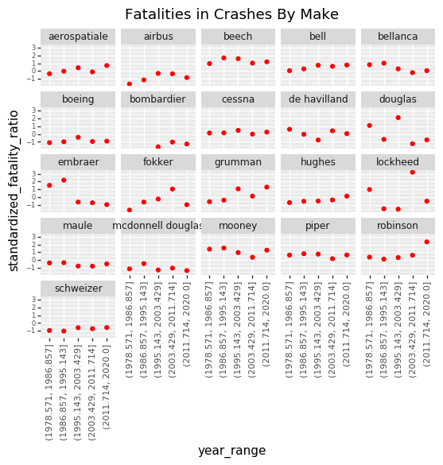

```python
plot = (ggplot(aes(x='year_range', y='standardized_fatality_ratio'), data=df7)
        + ggtitle("Fatalities in Crashes By Make")
        + geom_point(color='red')
        + facet_wrap('make')
        + stat_smooth(method='lm')
        + theme(axis_text_x = element_text(angle = 90, size = 8),
                axis_text_y = element_text(size = 6)))
plot
```

We get some interesting initial results.

There seems to be a propensity for large jet manufacturers such as boeing and airbus to have survivors when their planes crash, with the values being fairly low and consistent over time. This makes sense since these companies rely on good safety measures to maintain good rapport with the public.

This is in contrast to smaller, more personal plane manufacturers such as cessna and beech, which had an above average mortality rate which has remained fairly stable, pointing to the idea that mortality rates are not decreasing and that personal small aircraft seem to be more dangerous than commercial flying.

Interesting datapoints exist, such as in the case of "Robinson", where we see a fairly stable distribution for the first 4 points, followed by a large rise. Further research shows that Robinson helicopters seem to have had [increased susceptibility to mast bumping incidents from 2006 to 2016](https://www.latimes.com/projects/la-me-robinson-helicopters/), matching up with the spike in fatal crashes and thus decreased survivability of the passengers and crew. It seems the issue was big enough that there was a [lawsuit](https://www.rotorandwing.com/2018/06/28/lawsuit-claims-robinson-defects-caused-fatal-2016-crash-arizona/) brought against them after a helicopter suffered an in-flight breakup following mast bumping.

However, we can do further analysis to get a better interpretation of our major results.

# Linear Regression Analysis

We can perform a linear regression analysis and see if the make and year range can predict the fatality ratio. We can then see the details and see how well this model performs.

```python
#We denote categorical variables with C()
fit = ols('standardized_fatality_ratio ~ C(make) + C(year_range)', data=df7).fit()
fit_summary = fit.summary()
fit_summary
```

OLS Regression Results

| Dep. Variable: | standardized_fatality_ratio | R-squared: | 0.482 |
| --- | --- | --- | --- |
| Model: | OLS | Adj. R-squared: | 0.323 |
| Method: | Least Squares | F-statistic: | 3.025 |
| Date: | Mon, 18 May 2020 | Prob (F-statistic): | 0.000122 |
| Time: | 21:04:39 | Log-Likelihood: | -109.70 |
| No. Observations: | 103 | AIC: | 269.4 |
| Df Residuals: | 78 | BIC: | 335.3 |
| Df Model: | 24 |  |  |
| Covariance Type: | nonrobust |  |  |

|  | coef | std err | t | P>\|t\| | [0.025 | 0.975] |
| --- | --- | --- | --- | --- | --- | --- |
| Intercept | 0.1058 | 0.301 | 0.352 | 0.726 | -0.493 | 0.704 |
| C(make)[T.airbus] | -0.9911 | 0.510 | -1.943 | 0.056 | -2.007 | 0.025 |
| C(make)[T.beech] | 1.1569 | 0.510 | 2.268 | 0.026 | 0.141 | 2.173 |
| C(make)[T.bell] | 0.3581 | 0.510 | 0.702 | 0.485 | -0.658 | 1.374 |
| C(make)[T.bellanca] | 0.2586 | 0.510 | 0.507 | 0.614 | -0.757 | 1.274 |
| C(make)[T.boeing] | -1.0044 | 0.510 | -1.969 | 0.053 | -2.020 | 0.011 |
| C(make)[T.bombardier] | -1.4713 | 0.593 | -2.482 | 0.015 | -2.651 | -0.291 |
| C(make)[T.cessna] | 0.0696 | 0.510 | 0.136 | 0.892 | -0.946 | 1.085 |
| C(make)[T.de havilland] | -0.0709 | 0.510 | -0.139 | 0.890 | -1.087 | 0.945 |
| C(make)[T.douglas] | -0.0204 | 0.510 | -0.040 | 0.968 | -1.036 | 0.995 |
| C(make)[T.embraer] | 0.1401 | 0.510 | 0.275 | 0.784 | -0.876 | 1.156 |
| C(make)[T.fokker] | -0.6294 | 0.510 | -1.234 | 0.221 | -1.645 | 0.386 |
| C(make)[T.grumman] | 0.1656 | 0.510 | 0.325 | 0.746 | -0.850 | 1.181 |
| C(make)[T.hughes] | -0.5314 | 0.510 | -1.042 | 0.301 | -1.547 | 0.484 |
| C(make)[T.lockheed] | -0.0113 | 0.510 | -0.022 | 0.982 | -1.027 | 1.004 |
| C(make)[T.maule] | -0.6729 | 0.510 | -1.319 | 0.191 | -1.689 | 0.343 |
| C(make)[T.mcdonnell douglas] | -1.1748 | 0.510 | -2.303 | 0.024 | -2.191 | -0.159 |
| C(make)[T.mooney] | 0.9858 | 0.510 | 1.932 | 0.057 | -0.030 | 2.001 |
| C(make)[T.piper] | 0.4867 | 0.510 | 0.954 | 0.343 | -0.529 | 1.502 |
| C(make)[T.robinson] | 0.6335 | 0.510 | 1.242 | 0.218 | -0.382 | 1.649 |
| C(make)[T.schweizer] | -0.8967 | 0.510 | -1.758 | 0.083 | -1.912 | 0.119 |
| C(year_range)[T.Interval(1970.286, 1978.571, closed='right')] | 3.156e-18 | 7.03e-17 | 0.045 | 0.964 | -1.37e-16 | 1.43e-16 |
| C(year_range)[T.Interval(1978.571, 1986.857, closed='right')] | -0.0184 | 0.172 | -0.107 | 0.915 | -0.361 | 0.324 |
| C(year_range)[T.Interval(1986.857, 1995.143, closed='right')] | -0.0184 | 0.172 | -0.107 | 0.915 | -0.361 | 0.324 |
| C(year_range)[T.Interval(1995.143, 2003.429, closed='right')] | 0.0475 | 0.169 | 0.281 | 0.780 | -0.289 | 0.384 |
| C(year_range)[T.Interval(2003.429, 2011.714, closed='right')] | 0.0475 | 0.169 | 0.281 | 0.780 | -0.289 | 0.384 |
| C(year_range)[T.Interval(2011.714, 2020.0, closed='right')] | 0.0475 | 0.169 | 0.281 | 0.780 | -0.289 | 0.384 |

| Omnibus: | 28.595 | Durbin-Watson: | 2.111 |
| --- | --- | --- | --- |
| Prob(Omnibus): | 0.000 | Jarque-Bera (JB): | 68.651 |
| Skew: | 1.005 | Prob(JB): | 1.24e-15 |
| Kurtosis: | 6.457 | Cond. No. | 4.74e+17 |

Warnings:  
[1] Standard Errors assume that the covariance matrix of the errors is correctly specified.  
[2] The smallest eigenvalue is 5.7e-34. This might indicate that there are  
strong multicollinearity problems or that the design matrix is singular.

Looking at our regression summary, we can see that our adjusted R-squared value isn't very high, showing that our model doesn't fit extremely well. However, the f-statistic shows us that there is a good amount of linear relationship between the target variable and feature variables.

We can see the general trends between the maker and the chance of a fatality in a crash, with boeiing and bombardier being fairly low while beech seems to be the highest. As for the year ranges, we can see that they are not decreasing over time, meaning that if the data model is accurate, then it's not necessarily the case that survival chances have gone up of living through a plane crash since the 70's.

As for the accuracy and representation of the model, it's obvious there are other factors that affect fatality rates, but the makes aren't completely inconsequential.

# Conclusion

In conclusion we can't say that the chances of surviving a crash has increased over time in for all makes based on the analysis we did. Some considerations would be to take the fatality/passenger ratio per crash and evaluate that rather than splitting it up by make, and seeing what trends appear and whether there is an overall increase in survival rates. Furthermore, there are other variables that must be responsible for the fatalities, date and make don't seem to be the strictest of factors in this analysis, yet they did have some effect. We could also see some manufacturers were fairly consistent while others had periodic problems that cannot be easily predicted by this model. So in that sense, some makes are erratic while others are fairly stable in their manufacturing, but there doesn't seem to be a good way to predict when a make will suffer issues.